# Overview of scNMT data

Max Frank

5/28/2020

# Contents

First we need to download the data. We provide a subset of the full raw data. It is about 2.6 GB in size. Please set your working directory to where you stored this vignette and make sure that enough disk space is available.

```r
workdir <- "/home/max/code/single_cell_course/" # Change to directory where this vignette is stored
knitr::opts_knit$set(root.dir = workdir)
```

```r
#system("curl ...")
#system("unzip gastrulation_data.zip -d gastrulation_data")
```

Load all necessary libraries.

```r
library(data.table)
library(dplyr)
library(Seurat)
library(ggplot2)
library(MOFA2)
```

```r
# Define stage colors
stage_colors_acc <- c(
  "E4.5"="#eff3ff",
  "E5.5"="#9ecae1",
  "E6.5"="#3182bd",
  "E7.5"="#08519c"
)
stage_colors_met <- c(
  "E4.5"="#FDCC8A",
  "E5.5"="#FC8D59",
  "E6.5"="#E34A33",
  "E7.5"="#600707"
)

stage_colors_rna <- c(
  E4.5="#B2E2E2",
  E5.5="#66C2A4",
  E6.5="#2CA25F",
  E7.5="#006D2C"
)
```

# 1 Introduction

As you have heard, scNMT-seq allows the simultaneous profiling of transcriptome, methylome and chromatin accessibility in a single cell. We will now see how such a dataset can be analyzed in practice.

In particular we will be working with the data from the following study: [Multi-omics profiling of mouse gastrulation at single-cell resolution](https://www.nature.com/articles/s41586-019-1825-8). This study sequenced mouse embryonic stem cells as they undergo the process of gastrulation, during which the three primary germ layers are formed.

Later on we will use MOFA to analyze the three layers together, but in this tutorial we just want to get an overview of each layer separately. This should make it clear how the data of each layer looks like and how each of the layers changes over the course of mouse development. We will also reproduce some of the panels in Figure 1 of the paper. Note that the plots will not exactly match the figures since we are using slightly different tools and preprocessing strategies.

# 2 Data analysis

## 2.1 Metadata

The first step in every single-cell experiment is to get the data into a usable format and to do quality control. Since these steps can often be quite resource intensive, we already provide preprocessed data for you. If you are interested in the preprocessing you can have a look at the [full analysis folder of the paper](https://github.com/rargelaguet/scnmt_gastrulation). You can also find links to the full data there. Here we provide you with a metadata file that will give an overview of the quality control and links samples across the different layers. Please have a look at the metadata table.

```r
metadata <- fread("gastrulation_data/sample_metadata_filtered_clean.txt")
metadata
```

```
##                        sample pass_rnaQC pass_metQC pass_accQC stage
##    1: E4.5-5.5_new_Plate3_E09       TRUE       TRUE       TRUE  E4.5
##    2: E4.5-5.5_new_Plate3_G09       TRUE      FALSE      FALSE  E4.5
##    3: E4.5-5.5_new_Plate3_H09       TRUE       TRUE       TRUE  E4.5
##    4: E4.5-5.5_new_Plate3_B09       TRUE      FALSE      FALSE  E4.5
##    5: E4.5-5.5_new_Plate4_G01       TRUE       TRUE       TRUE  E4.5
##   ---
## 2174:        PS_VE_Plate6_D10       TRUE         NA         NA  E7.5
## 2175:        PS_VE_Plate6_F10       TRUE         NA         NA  E7.5
## 2176:        PS_VE_Plate6_A10       TRUE         NA         NA  E7.5
## 2177:        PS_VE_Plate6_B10       TRUE         NA         NA  E7.5
## 2178:        PS_VE_Plate6_H10       TRUE         NA         NA  E7.5
##                lineage         stage_lineage
##    1:         Epiblast         E4.5_Epiblast
##    2:         Epiblast         E4.5_Epiblast
##    3:         Epiblast         E4.5_Epiblast
##    4:         Epiblast         E4.5_Epiblast
##    5:         Epiblast         E4.5_Epiblast
##   ---
## 2174:         Endoderm         E7.5_Endoderm
## 2175: Primitive_Streak E7.5_Primitive_Streak
## 2176:         Mesoderm         E7.5_Mesoderm
## 2177: Primitive_Streak E7.5_Primitive_Streak
## 2178:         Mesoderm         E7.5_Mesoderm
```

Note that every cell already has annotations for the lineage it belongs to and a `stage` column. The stage column corresponds to the embryonic day the cells were sequenced, whereas the lineage labels come from a mapping to an extensive (100.000 cells) 10X single-cell RNA-seq atlas that annotated these celltypes. For more informations on the mapping please have a look in the methods section of the paper and also check out the mouse gastrulation atlas [here](https://www.nature.com/articles/s41586-019-0933-9).

## 2.2 RNA layer

### 2.2.1 Preprocessing

The RNA data is stored in a seurat object that we will use for further analysis. This section will be a quick recap of things you learned yesterday.

```r
rna <- readRDS("gastrulation_data/rna/seurat_object.rds")
rna
```

```
## An object of class Seurat
## 18345 features across 2147 samples within 1 assay
## Active assay: RNA (18345 features, 0 variable features)
```

We use `Seurat` to identify highly variable genes.

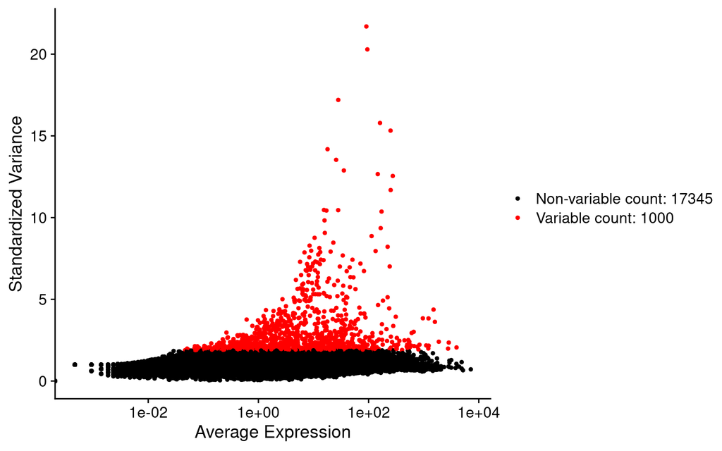

```r
# Add the metadata table to the seurat object
rna <- AddMetaData(rna, metadata = data.frame(metadata, row.names = metadata$sample))
# Make sure only cells that pass the qc are used
rna <- rna[, rna$pass_rnaQC == TRUE]
# Log t
rna <- NormalizeData(rna)
rna <- FindVariableFeatures(rna, nfeatures = 1000)

VariableFeaturePlot(rna)
```

We will also center and scale the data to remove library size effects.

```r
all.genes <- rownames(rna)
rna <- ScaleData(rna, features = all.genes)
```

### 2.2.2 Dimensionality reduction

Now we can perform dimensionality reduction by PCA followed by UMAP.

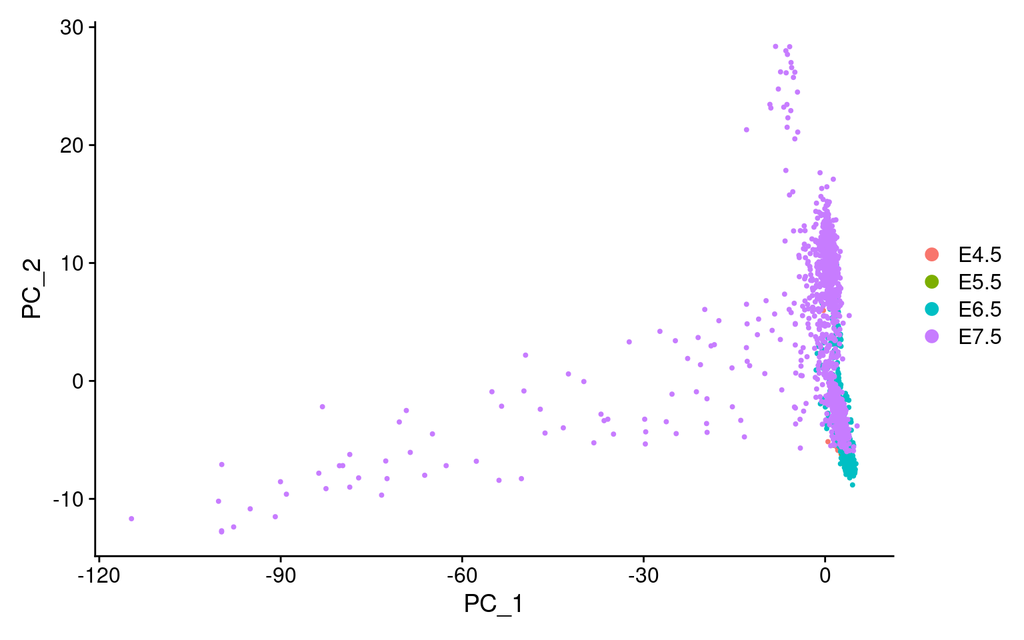

```r
rna <- RunPCA(rna, features = VariableFeatures(object = rna))

DimPlot(rna, reduction = "pca", group.by = "stage")
```

The first 2 principal components seem to capture some variation in the latest stage. But there is still a lot of variation not explained by the first 2 components.

**Question: How would you determine how many PC’s to use for further analysis?**

**Answer**

There are multiple ways to determine the dimensionality of a dataset. The quickest one is to plot the percentage of variance explained by each PC.

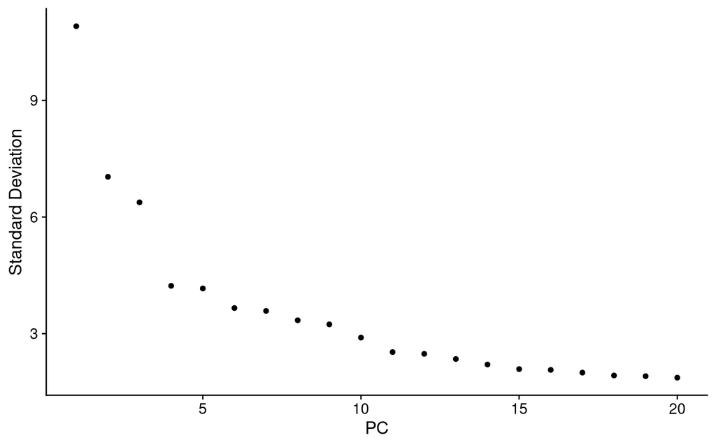

```r
ElbowPlot(rna)
```

Let’s run umap to vizualize the dataset.

```r
rna <- RunUMAP(rna, dims = 1:10, n.neighbors = 20, min.dist = 0.7)
```

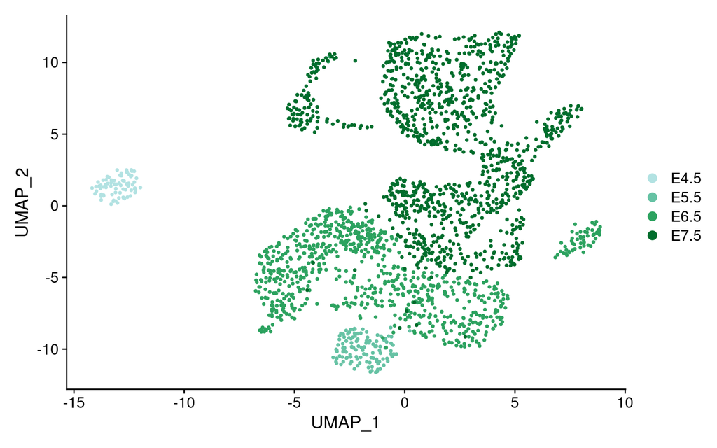

```r
DimPlot(rna, reduction = "umap", group.by = "stage") + scale_color_manual(values = stage_colors_rna)
```

The rna expression clearly separates the stages. Since we used different analysis tools than the authors of the paper our plot looks slightly different to [Figure 1b](https://www.nature.com/articles/s41586-019-1825-8/figures/1).